# ▒ 고급회귀분석 ▒

### **0. 환경설정**

```r
#install.packages("factoextra")
#install.packages("plotmo")
#install.packages("ggplot2")
#install.packages("pls")
#install.packages("glmnet")
library(factoextra)
library(plotmo)
library(ggplot2)
library(pls)
library(glmnet)
library(readxl)
```

**[Define function]** Correlation panel

```r
panel.cor             <- function(x, y){
  usr                 <- par("usr"); on.exit(par(usr))
  par(usr = c(0, 1, 0, 1))
  r                   <- round(cor(x, y), digits = 2)
  txt                 <- paste0("   R = ", r)
  text(0.5, 0.3, txt, cex = 1)
}
```

**[Define function]** Customize upper panel

```r
upper.panel<-function(x, y){
  points(x, y, pch = 19, col = "#FC4E07")
}
```

**[option]** options by plot

```r
options(repr.plot.width = 6, repr.plot.height = 5)
```

### **1. 예제 데이터**

**[데이터 다운로드]**

- C드라이브에 [R_project] 폴더 생성
- [R_project] 폴더에 [DAT] 폴더 생성
- 데이터 스토어에서 샘플데이터(3.아파트_주소기반_주택지역특성시세정보_DB.xlsx)를 “C:/R_project/DAT/”에 다운로드 (https://www.datastore.or.kr/file/detail?id=2c0a9616-4d78-403c-9d77-3db2effb2a74&page=1&viewCount=10&sort=1&order=1&source=1&keyword=%EC%95%84%ED%8C%8C%ED%8A%B8)
- 서울/수도권 및 5대광역시 아파트에 대한 주소테이블 외 4개의 테이블(정보집단)로 구성되며 각각 주택특성정보, 지역특성정보, 가격/신뢰등급/예상회수율정보 테이블로 이루어져 있고, 각 테이블간은 고유키값(NUM)으로 연계되어 있음

**[데이터 호출]**

```r
path                  <- "C:/R_project/DAT/3.아파트_주소기반_주택지역특성시세정보_DB.xlsx"
sheet.names           <- excel_sheets(path)

df1                   <- read_excel(path, sheet.names[1])
df2                   <- read_excel(path, sheet.names[2])
df3                   <- read_excel(path, sheet.names[3])
df4                   <- read_excel(path, sheet.names[4])
data                  <- Reduce(function(x, y) merge(x, y, all=FALSE), list(df1, df2, df3, df4))

data$LAND_ACCESS      <- as.numeric(as.character(data$LAND_ACCESS))
data1                 <- data[complete.cases(data), c(97, 41, 93, 49:53, 25:27)]
head(data1, 5)
```

```
##   AVM_RECOVER LAND_ACCESS APPRAISAL_FEE HOUSEHOLD      PPH
## 1       99000     8920000          3850      4577 2.093948
## 2      114000     8920000          4550      4577 2.093948
## 3      121000     8920000          4550      4577 2.093948
## 4       65500    19000000          2485      4577 2.093948
## 5      121000    14500000          4550      4577 2.093948
##   SINGLE_HOUSEHOLD SUPPLY EXCESS_DEMAND PRIV_AREA PUB_AREA SUM_AREA
## 1             2207   7872          2454     94.51    66.27   160.78
## 2             2207   7872          2454    126.34    88.60   214.94
## 3             2207   7872          2454    147.31   103.30   250.61
## 4             2207   7872          2454    105.07    13.68   118.75
## 5             2207   8330          3753    140.78   100.84   241.62
```

- AVM_RECOVER : 회수가능금액
- LAND_ACCESS : 개별공시지가
- APPRAISAL_FEE : 감정평가수수료
- HOUSEHOLD : 가구수
- PPH : 세대당인구수
- SINGLE_HOUSEHOLD : 1인가구수
- SUPPLY : 주택수
- EXCESS_DEMAND : 초과수요
- PRIV_AREA : 전유면적
- PUB_AREA : 공유면적
- SUM_AREA : 계약면적

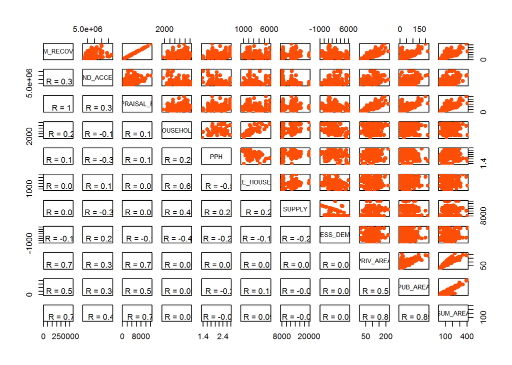

```r
pairs(data1, lower.panel = panel.cor, upper.panel = upper.panel)
```

### **2.주성분 회귀분석**

**[주성분 분석]**

```r
data_pca              <- princomp(data1[-1], cor = TRUE)
summary(data_pca)
```

```
## Importance of components:
##                           Comp.1    Comp.2    Comp.3    Comp.4     Comp.5
## Standard deviation     1.8496124 1.5183578 1.2993739 0.8882477 0.81567976
## Proportion of Variance 0.3421066 0.2305410 0.1688372 0.0788984 0.06653335
## Cumulative Proportion  0.3421066 0.5726477 0.7414849 0.8203833 0.88691666
##                            Comp.6     Comp.7     Comp.8      Comp.9
## Standard deviation     0.68865351 0.61569205 0.49311742 0.185332745
## Proportion of Variance 0.04742437 0.03790767 0.02431648 0.003434823
## Cumulative Proportion  0.93434103 0.97224870 0.99656518 1.000000000
##                        Comp.10
## Standard deviation           0
## Proportion of Variance       0
## Cumulative Proportion        1
```

```r
summary(data_pca)$loadings
```

```
##
## Loadings:
##                  Comp.1 Comp.2 Comp.3 Comp.4 Comp.5 Comp.6 Comp.7 Comp.8
## LAND_ACCESS       0.320  0.249  0.215  0.292  0.608  0.283  0.346  0.362
## APPRAISAL_FEE     0.430 -0.159 -0.210  0.183  0.266  0.125        -0.789
## HOUSEHOLD               -0.576  0.209         0.235 -0.449  0.129  0.101
## PPH                     -0.283 -0.623         0.196 -0.349  0.254  0.188
## SINGLE_HOUSEHOLD        -0.298  0.656               -0.186 -0.158
## SUPPLY                  -0.452        -0.671  0.177  0.536  0.139
## EXCESS_DEMAND            0.450        -0.615  0.369 -0.497        -0.167
## PRIV_AREA         0.461        -0.189                      -0.650  0.357
## PUB_AREA          0.453               -0.120 -0.483         0.572
## SUM_AREA          0.520               -0.119 -0.248                0.190
##                  Comp.9 Comp.10
## LAND_ACCESS
## APPRAISAL_FEE
## HOUSEHOLD        -0.578
## PPH               0.504
## SINGLE_HOUSEHOLD  0.637
## SUPPLY
## EXCESS_DEMAND
## PRIV_AREA                0.429
## PUB_AREA                 0.458
## SUM_AREA                -0.779
##
##                Comp.1 Comp.2 Comp.3 Comp.4 Comp.5 Comp.6 Comp.7 Comp.8
## SS loadings       1.0    1.0    1.0    1.0    1.0    1.0    1.0    1.0
## Proportion Var    0.1    0.1    0.1    0.1    0.1    0.1    0.1    0.1
## Cumulative Var    0.1    0.2    0.3    0.4    0.5    0.6    0.7    0.8
##                Comp.9 Comp.10
## SS loadings       1.0     1.0
## Proportion Var    0.1     0.1
## Cumulative Var    0.9     1.0
```

**[scree plot]**

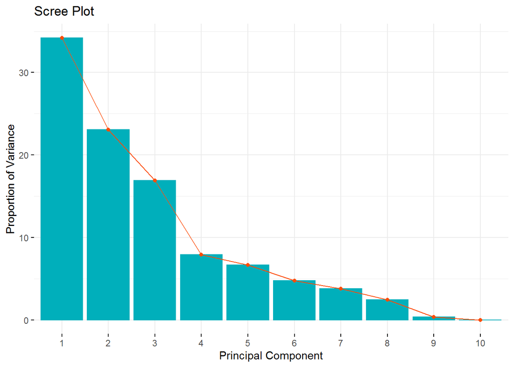

```r
fviz_eig(data_pca, main = "Scree Plot", barcolor = "#00AFBB", barfill = "#00AFBB",
         linecolor = "#FC4E07", xlab = "Principal Component", ylab = "Proportion of Variance")
```

**[score값 계산]**

```r
data_score            <- data.frame(summary(data_pca)$score)
```

**[모형적합]** 모든 주성분을 이용한 회귀모형

```r
data_score_lm         <- lm(data1$AVM_RECOVER  ~ Comp.1 + Comp.2 + Comp.3 + Comp.4 + Comp.5 + Comp.6 + Comp.7 +
                              Comp.8 + Comp.9 + Comp.10 , data = data_score)
summary(data_score_lm)
```

```
##
## Call:
## lm(formula = data1$AVM_RECOVER ~ Comp.1 + Comp.2 + Comp.3 + Comp.4 +
##     Comp.5 + Comp.6 + Comp.7 + Comp.8 + Comp.9 + Comp.10, data = data_score)
##
## Residuals:
##     Min      1Q  Median      3Q     Max
## -8301.0  -878.0    -1.8   754.1  6771.8
##
## Coefficients:
##               Estimate Std. Error t value Pr(>|t|)
## (Intercept)  9.314e+04  1.614e+02 577.078  < 2e-16 ***
## Comp.1       1.750e+04  5.291e+01 330.741  < 2e-16 ***
## Comp.2      -6.578e+03  7.190e+01 -91.496  < 2e-16 ***
## Comp.3      -8.505e+03  9.485e+01 -89.670  < 2e-16 ***
## Comp.4       7.827e+03  2.883e+02  27.151  < 2e-16 ***
## Comp.5       1.180e+04  8.301e+02  14.216  < 2e-16 ***
## Comp.6       5.584e+03  4.317e+02  12.934  < 2e-16 ***
## Comp.7      -3.942e+03  1.407e+03  -2.802  0.00528 **
## Comp.8      -3.128e+04  3.514e+02 -89.016  < 2e-16 ***
## Comp.9      -3.797e+03  2.583e+03  -1.470  0.14230
## Comp.10     -9.304e+17  7.051e+17  -1.320  0.18762
## ---
## Signif. codes:  0 '***' 0.001 '**' 0.01 '*' 0.05 '.' 0.1 ' ' 1
##
## Residual standard error: 2157 on 484 degrees of freedom
## Multiple R-squared:  0.9972, Adjusted R-squared:  0.9972
## F-statistic: 1.753e+04 on 10 and 484 DF,  p-value: < 2.2e-16
```

→ 제9주성분과 제10주성분을 제외하고 모두 유의하다.

**[모형적합]** 제8주성분까지 이용한 회귀모형

```r
data_score_lm         <- lm(data1$AVM_RECOVER ~ Comp.1 + Comp.2 + Comp.3 + Comp.4 + Comp.5 + Comp.6 + Comp.7 +
                              Comp.8, data = data_score)
summary(data_score_lm)
```

```
##
## Call:
## lm(formula = data1$AVM_RECOVER ~ Comp.1 + Comp.2 + Comp.3 + Comp.4 +
##     Comp.5 + Comp.6 + Comp.7 + Comp.8, data = data_score)
##
## Residuals:
##     Min      1Q  Median      3Q     Max
## -8328.3  -850.7   -43.2   780.3  6637.0
##
## Coefficients:
##              Estimate Std. Error t value Pr(>|t|)
## (Intercept)  92972.93      97.01  958.35   <2e-16 ***
## Comp.1       17510.38      52.45  333.84   <2e-16 ***
## Comp.2       -6622.02      63.89 -103.64   <2e-16 ***
## Comp.3       -8428.05      74.66 -112.88   <2e-16 ***
## Comp.4        7474.57     109.22   68.44   <2e-16 ***
## Comp.5       10716.58     118.94   90.10   <2e-16 ***
## Comp.6        5045.49     140.87   35.82   <2e-16 ***
## Comp.7       -2097.39     157.57  -13.31   <2e-16 ***
## Comp.8      -31668.60     196.74 -160.97   <2e-16 ***
## ---
## Signif. codes:  0 '***' 0.001 '**' 0.01 '*' 0.05 '.' 0.1 ' ' 1
##
## Residual standard error: 2158 on 486 degrees of freedom
## Multiple R-squared:  0.9972, Adjusted R-squared:  0.9972
## F-statistic: 2.189e+04 on 8 and 486 DF,  p-value: < 2.2e-16
```

→ 제 8주성분까지 사용하더라도, *0.9972*(Adjusted R-squared)로 모든 주성분을 사용한 모형과 차이가 없음을 확인할 수 있다.

### **3. 부분 최소 제곱**

**[모형적합]** 기본 모형

```r
set.seed(1)
data_pls1             <- plsr(AVM_RECOVER ~ ., ncomp = 10, data = data1, validation = "CV")
summary(data_pls1)
```

```
## Data:    X dimension: 495 10
##  Y dimension: 495 1
## Fit method: kernelpls
## Number of components considered: 10
##
## VALIDATION: RMSEP
## Cross-validated using 10 random segments.
##        (Intercept)  1 comps  2 comps  3 comps  4 comps  5 comps  6 comps
## CV           40735    37553    27746     6316     4152     2492     2184
## adjCV        40735    37544    27735     6209     4164     2493     2182
##        7 comps  8 comps  9 comps  10 comps
## CV        2189     2195     2198      2198
## adjCV     2186     2192     2195      2195
##
## TRAINING: % variance explained
##              1 comps  2 comps  3 comps  4 comps  5 comps  6 comps  7 comps
## X             100.00   100.00   100.00   100.00   100.00   100.00   100.00
## AVM_RECOVER    15.48    54.78    97.73    98.97    99.64    99.72    99.72
##              8 comps  9 comps  10 comps
## X             100.00   100.00    100.00
## AVM_RECOVER    99.72    99.72     99.72
```

**[모형적합]** 최적 성분수 결정

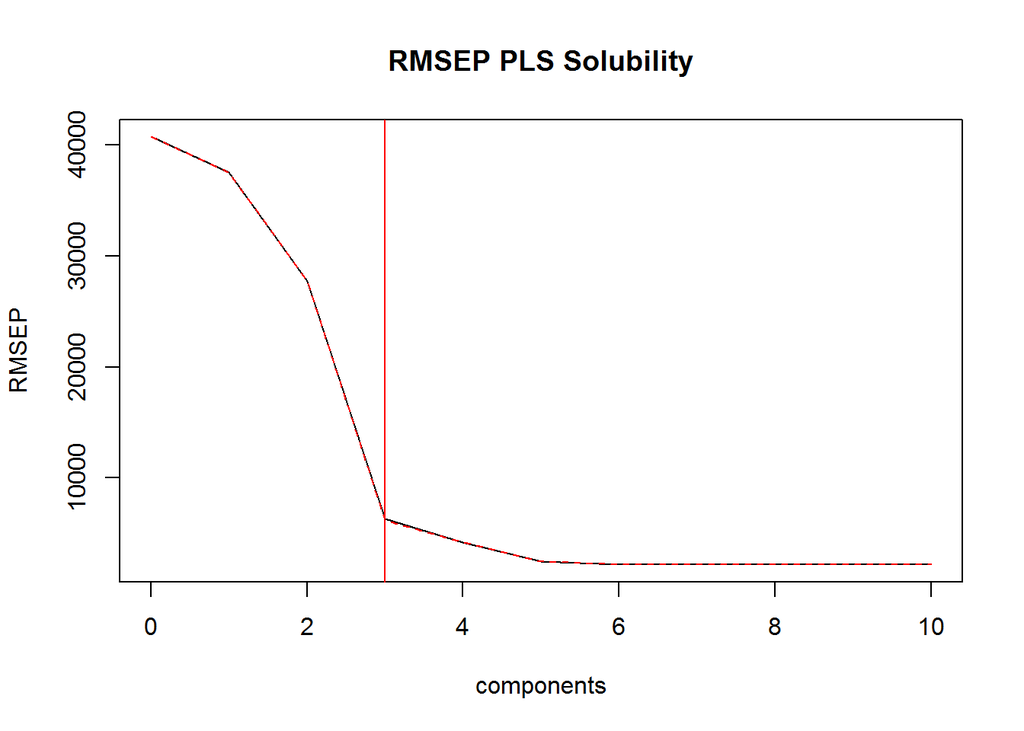

```r
pls.RMSEP             <- RMSEP(data_pls1)
plot(pls.RMSEP, main="RMSEP PLS Solubility", xlab="components")
min_comp              <- which.max(abs(diff(pls.RMSEP$val[2,,])))
abline(v = min_comp, col="red")
```

→ 성분의 개수가 *3*개까지 급격히 감소하므로 최적의 성분 개수는 *3*개

**[모형적합]** 최적의 성분 개수인 3개의 성분을 가지는 부분 최소 제곱 회귀 모형 적합

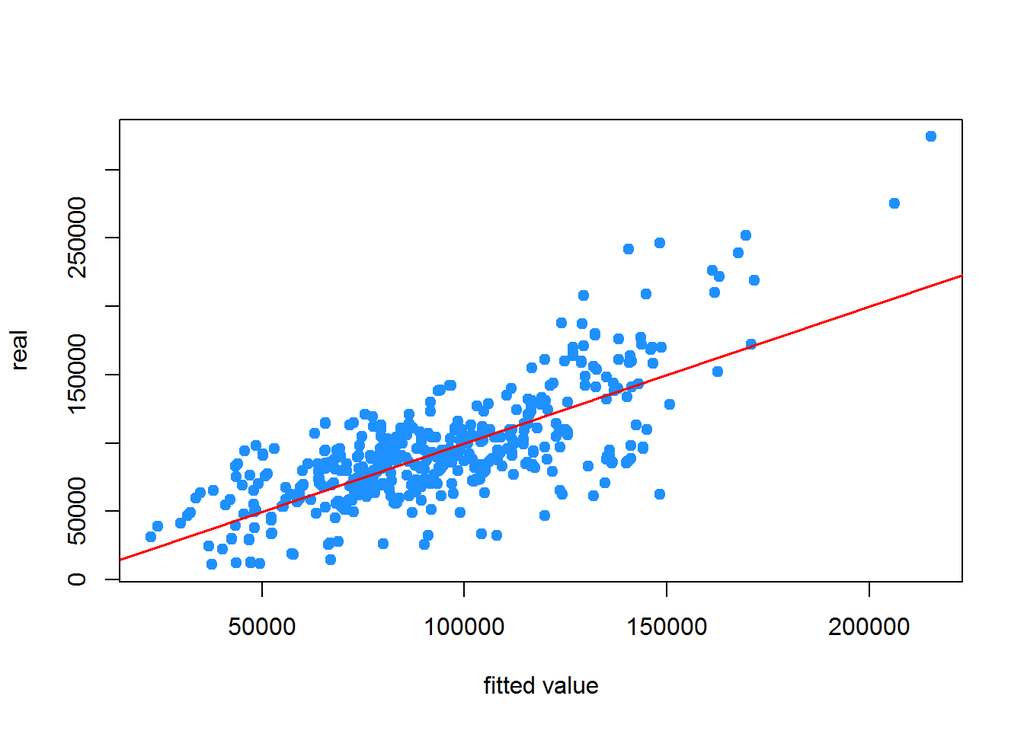

```r
set.seed(1)
data_pls2             <- plsr(AVM_RECOVER ~ ., ncomp = min_comp, data = data1)
plot(data_pls1$fitted.values[, , 2], data1$AVM_RECOVER, pch = 19,
     col = "dodgerblue", xlab = "fitted value", ylab = "real")
abline(0, 1, col = 2, lwd = 1.5)
```

### **4. Shrinkage Method**

**[상관성 확인]**

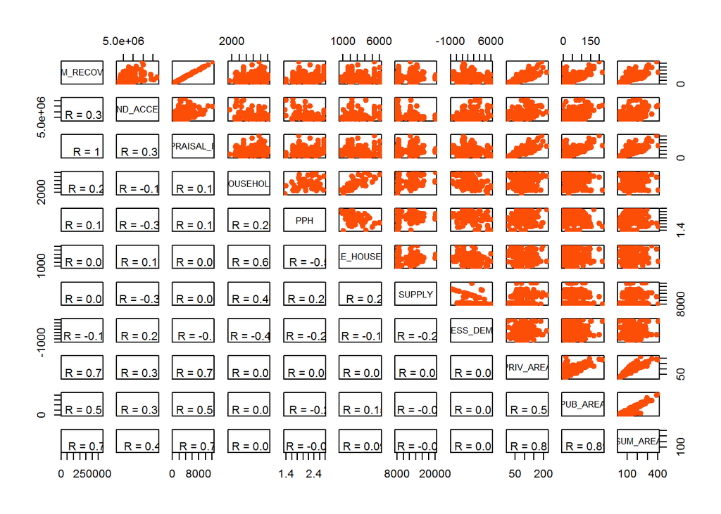

```r
pairs(data1, lower.panel = panel.cor, upper.panel = upper.panel)
```

**[변수 지정]** 반응 변수

```r
y                     <- data1[, 1]
```

**[변수 지정]** 설명 변수

```r
x                     <- data1[, -1]
```

**Ridge**

**[모형적합]** 기본모형

```r
set.seed(1)
ridge.fit             <- glmnet(as.matrix(x), y, alpha = 0) # alpha=0: ridge, 1: lasso
```

**[모형적합]** 최적 조율 모수

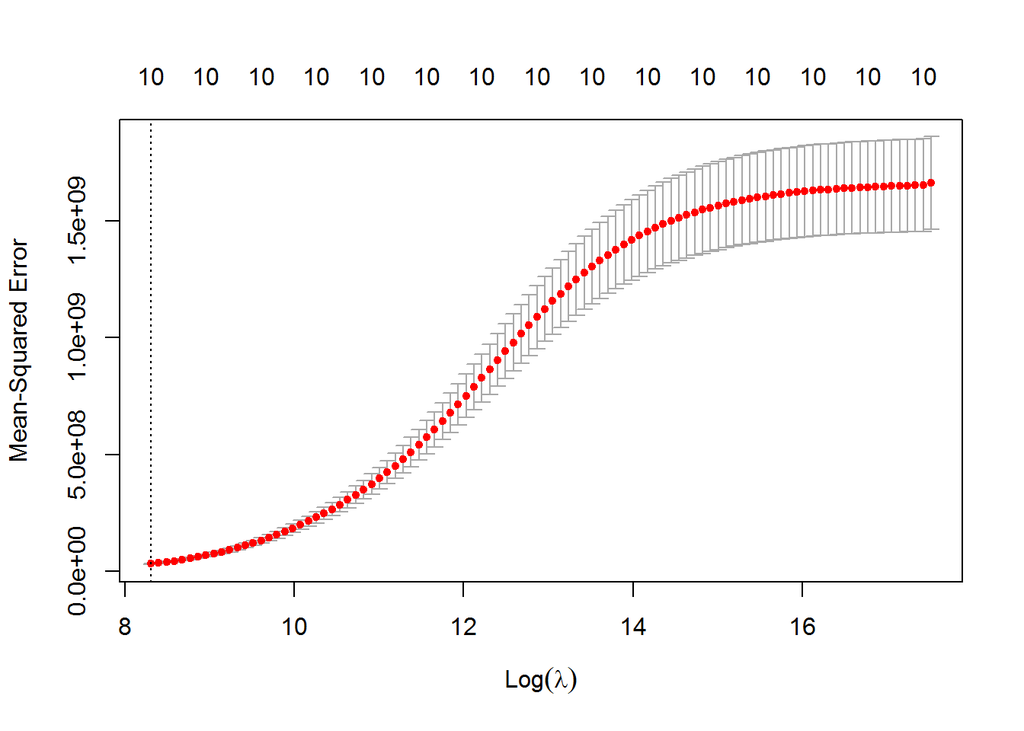

```r
set.seed(1234) # random number fix
cv.ridge              <- cv.glmnet(as.matrix(x), y, alpha = 0)
plot(cv.ridge)
```

```r
round(cv.ridge$lambda.min, 4)
```

```
## [1] 4059.499
```

→ shrinkage factor가 4059.499(log 변환 시 8.308815)일 때 MSE가 가장 작으므로 best model

**[결과]** Ridge 회귀계수

```r
coef(ridge.fit, s = cv.ridge$lambda.min)
```

```
## 11 x 1 sparse Matrix of class "dgCMatrix"
##                              1
## (Intercept)      -1.211962e+04
## LAND_ACCESS       7.047272e-04
## APPRAISAL_FEE     2.042581e+01
## HOUSEHOLD         3.833255e-01
## PPH               5.012970e+03
## SINGLE_HOUSEHOLD -3.376266e-01
## SUPPLY            9.760216e-02
## EXCESS_DEMAND    -9.235574e-01
## PRIV_AREA         9.168082e+01
## PUB_AREA          2.595837e+01
## SUM_AREA          3.824355e+01
```

→ 모든 변수의 계수가 추정됨

**[시각화]**

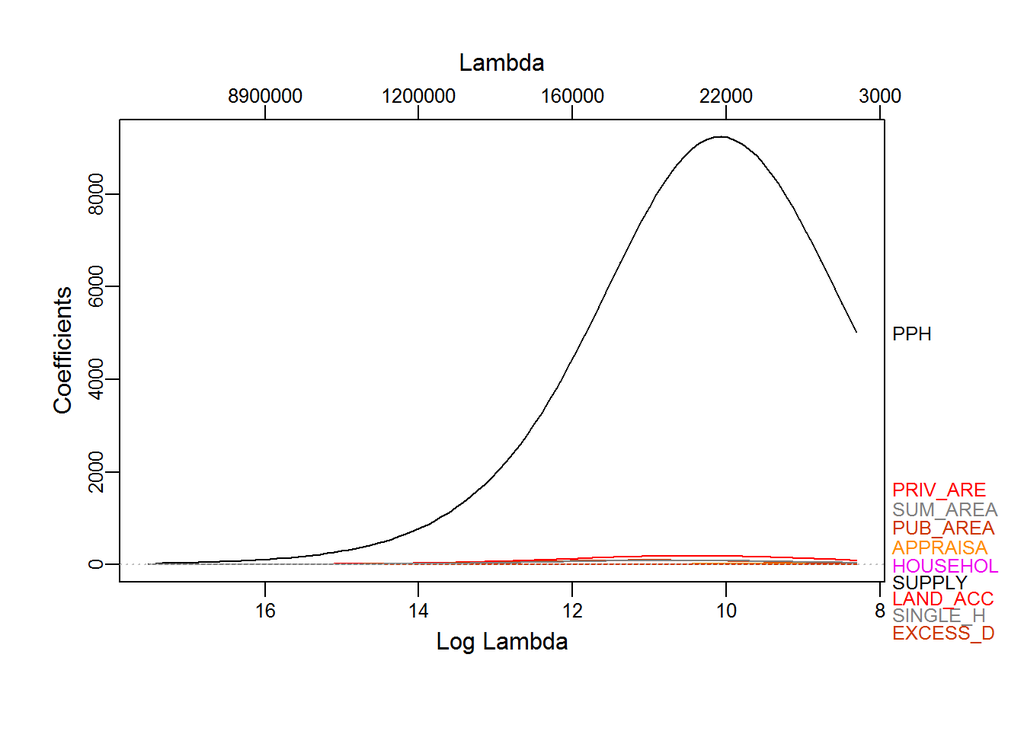

```r
plot_glmnet(ridge.fit, label = TRUE)
```

**Lasso**

**[모형적합]**

```r
lasso.fit             <- glmnet(as.matrix(x), y, alpha = 1)
```

**[모형적합]** 최적 조율 모수

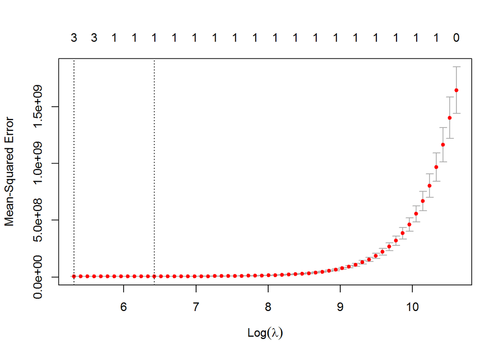

```r
set.seed(1234)
cv.lasso              <- cv.glmnet(as.matrix(x), y, alpha = 1)
plot(cv.lasso)
```

```r
round(cv.lasso$lambda.min, 4)
```

```
## [1] 202.0422
```

→ shrinkage factor가 202.0422(log 변환 시 5.308477) 일때 MSE가 가장 작으므로 best model

**[결과]** Lasso 회귀계수

```r
coef(lasso.fit, s = cv.lasso$lambda.min)
```

```
## 11 x 1 sparse Matrix of class "dgCMatrix"
##                             1
## (Intercept)      614.61425856
## LAND_ACCESS        .
## APPRAISAL_FEE     25.70150193
## HOUSEHOLD          0.03998688
## PPH                .
## SINGLE_HOUSEHOLD   .
## SUPPLY             .
## EXCESS_DEMAND      .
## PRIV_AREA          .
## PUB_AREA           .
## SUM_AREA           1.87468637
```

→ LAND_ACCESS, PPH, SINGLE_HOUSEHOLD, SUPPLY, EXCESS_DEMAND, PRIV_AREA, PUB_AREA이 제외되어 모형적합

**[시각화]**

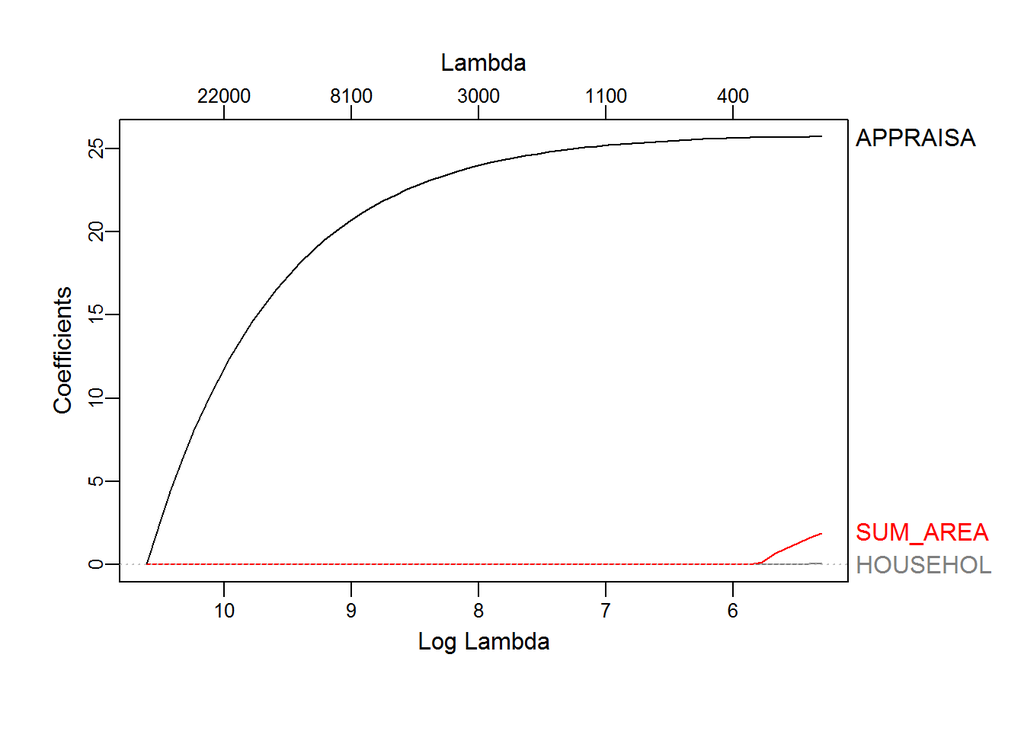

```r
plot_glmnet(lasso.fit, label = TRUE)
```

**Elasticnet**

**[모형적합]** 기본 모형

```r
elas.fit              <- glmnet(as.matrix(x), y, alpha = 0.5)
```

**[모형적합]** 최적 조율 모수

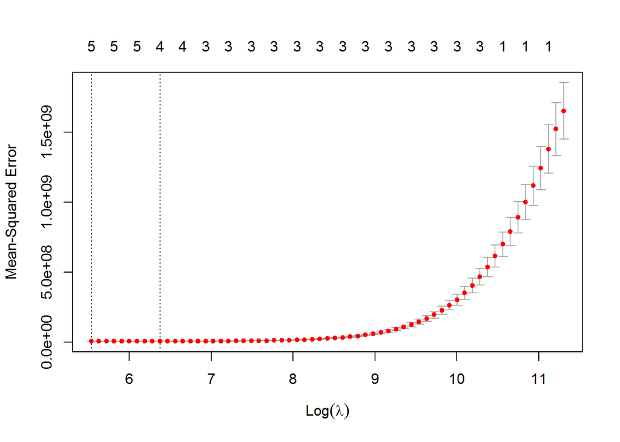

```r
set.seed(1234)
cv.elas               <- cv.glmnet(as.matrix(x), y, alpha = 0.5)
plot(cv.elas)
```

```r
round(cv.elas$lambda.min, 4)
```

```
## [1] 253.7768
```

→ shrinkage factor가 253.7768(log 변환 시 5.536455)일 때 MSE가 가장 작으므로 best model

**[결과]** Elasticnet 회귀계수

```r
coef(elas.fit, s = cv.elas$lambda.min)
```

```
## 11 x 1 sparse Matrix of class "dgCMatrix"
##                             1
## (Intercept)      327.94743078
## LAND_ACCESS        .
## APPRAISAL_FEE     25.52579836
## HOUSEHOLD          0.07152631
## PPH                .
## SINGLE_HOUSEHOLD   .
## SUPPLY             .
## EXCESS_DEMAND     -0.05178106
## PRIV_AREA          3.54657690
## PUB_AREA           .
## SUM_AREA           5.09747157
```

→ LAND_ACCESS, PPH, SINGLE_HOUSEHOLD, SUPPLY, PUB_AREA이 제외됨

**[시각화]**

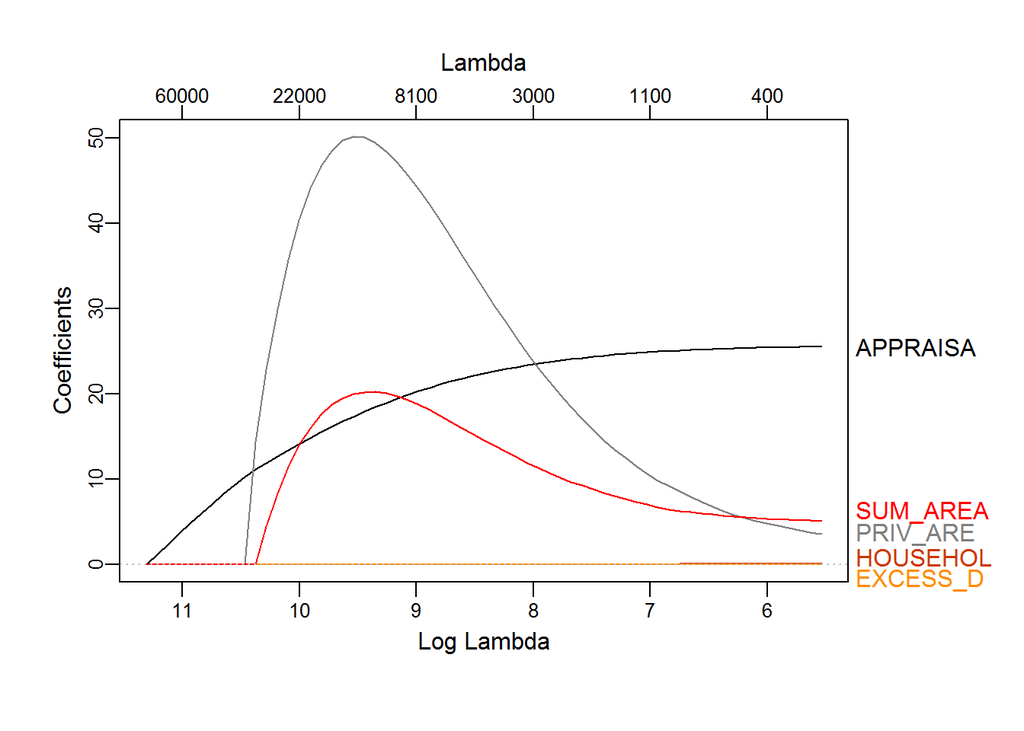

```r
plot_glmnet(elas.fit, label = TRUE)
```